# Regression exercise: Water salinity

Constance Delannoy

April 19, 2018

Dataset: CalCOFI; Over 60 years of oceanographic data

Questions: Is there a relationship between water salinity & water temperature? Can you predict the water temperature based on salinity?

Method: Linear regression

Findings: Temperature is not a good predictor of salinity except when paired with Depth and O2 concentration.

## Exploration and data cleaning

*Outcome variable*

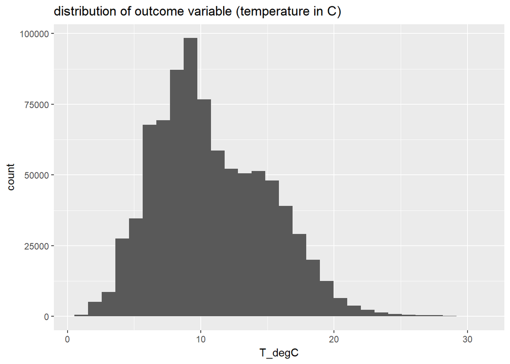

The number of NA values in the outcome variable is 10963. We filter the dataset to only keep rows without NAs.

We now turn to the independent variables.

*Independent variables*

The two main variables of interest seems decently normal as well, although it has outliers in both directions.

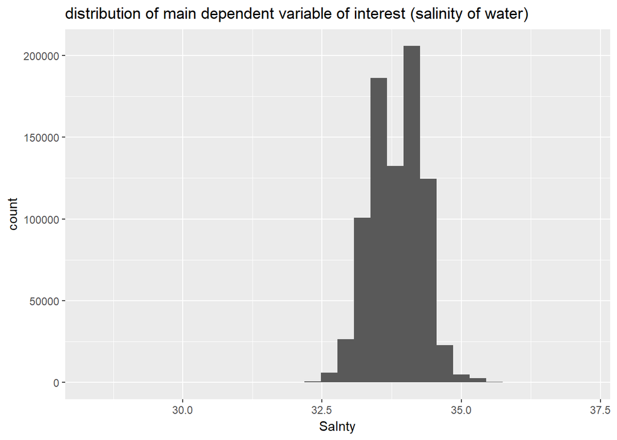

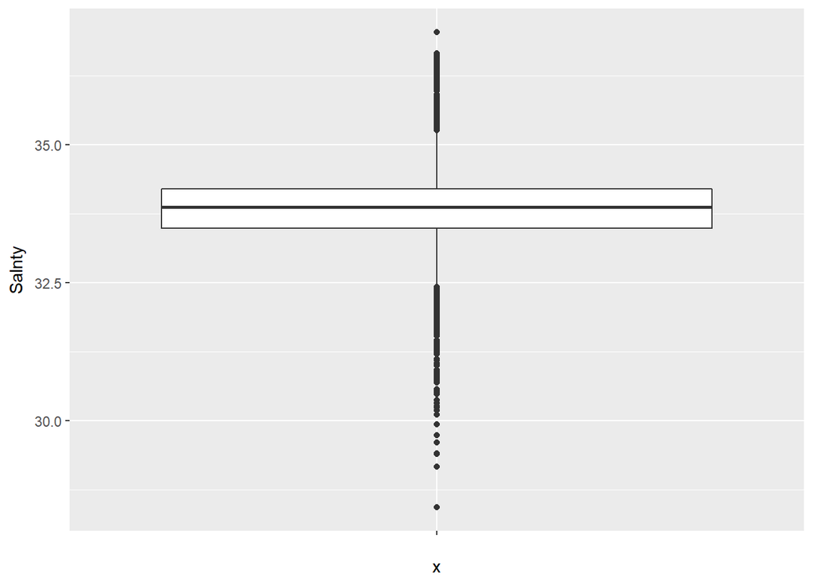

We look at the second measure of salinity, which is highly skewed. Because of this, we prefer to use the first measure of salinity as outcome variable, and drop the variable below from our dataset. In addition, R_SALINITY has a lot of NAs, which further comforts us in our decision to use Salnty as independent variable.

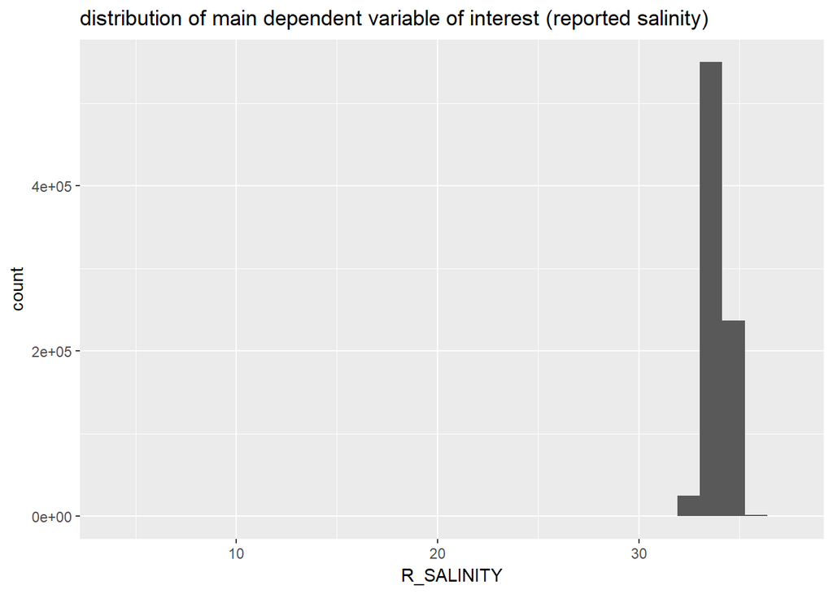

Before removing the variable from our data, we confirm that the two variables are correlated (which they are).

```
## The correlation between R_SALINITY and Salnty is 0.9974
```

We remove variables related to replication bottles because they are highly correlated with one another and because there are very few non-NA values.

As a next step, we check the amount of NAs in all of our columns. Some of them have more than 50% NA values (note we have already filtered out NA rows on our outcome variable). We remove these variables from our dataset.

|  | variable | sum_na |
| --- | --- | --- |
| 1 | BtlNum | 0.862790985393062 |
| 2 | ChlorA | 0.739528688358734 |
| 3 | Phaeop | 0.739529844611227 |
| 4 | PO4uM | 0.522101188280687 |
| 5 | SiO3uM | 0.59058139844114 |
| 6 | NO2uM | 0.609676908365834 |
| 7 | NO3uM | 0.609876940047152 |
| 8 | NH3uM | 0.924887525538727 |
| 9 | DarkAs | 0.973812037282205 |
| 10 | IncTim | 1 |
| 11 | LightP | 0.978434734749897 |
| 12 | R_SIO3 | 0.590572148421195 |
| 13 | R_PO4 | 0.522091938260742 |
| 14 | R_NO3 | 0.609867690027207 |
| 15 | R_NO2 | 0.609667658345888 |
| 16 | R_NH4 | 0.924864400488864 |
| 17 | R_CHLA | 0.739524063348762 |
| 18 | R_PHAEO | 0.739525219601255 |
| 19 | pH2 | 0.999988437475068 |
| 20 | pH1 | 0.999902874790574 |

Finally, we check the correlations of other variables in our dataset. We remove the following variables:

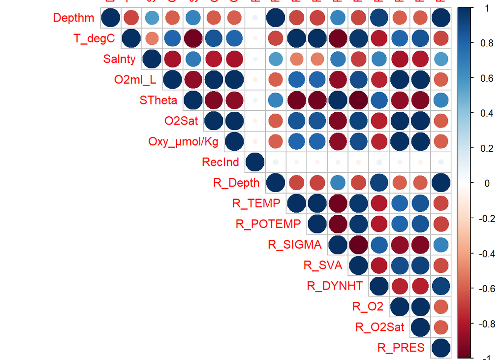

The resulting dataset has 4 columns and 661489.

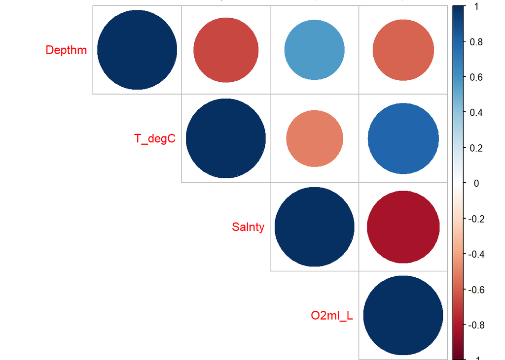

## Model

|  | *Dependent variable:* |  |  |
| --- | --- | --- | --- |
|  | Salnty |  |  |
|  | Standard lm | lm with log(depth) | lm with Tonly |
|  | (1) | (2) | (3) |
| Depthm | 0.0004*** | 0.0004*** |  |
|  | (0.00000) | (0.00000) |  |
| T_degC | 0.061*** | 0.067*** | -0.055*** |
|  | (0.0001) | (0.0001) | (0.0001) |
| O2ml_L | -0.245*** | -0.236*** |  |
|  | (0.0002) | (0.0002) |  |
| log_Depthm |  | 0.038*** |  |
|  |  | (0.0004) |  |
| Constant | 33.906*** | 33.643*** | 34.434*** |
|  | (0.001) | (0.003) | (0.001) |
| Observations | 661,489 | 637,730 | 661,489 |
| R<sup>2</sup> | 0.786 | 0.802 | 0.256 |
| Adjusted R<sup>2</sup> | 0.786 | 0.802 | 0.256 |
| Residual Std. Error | 0.213 (df = 661485) | 0.203 (df = 637725) | 0.397 (df = 661487) |
| F Statistic | 812,217.500*** (df = 3; 661485) | 645,569.600*** (df = 4; 637725) | 227,416.000*** (df = 1; 661487) |
| *Note:* | p<0.1; p<0.05; p<0.01 |  |  |

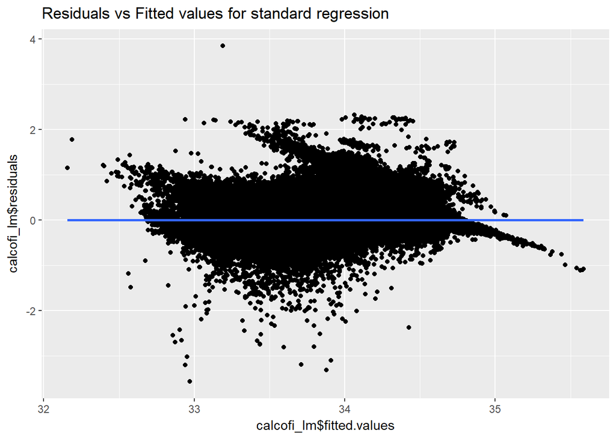

The residuals are somewhat normal, but there seems to be some negative trend.

To further investigate, we plot the outcome variable on each dependent variable.

It seems that salinity values are concentrated for one measure of Depth. In a separate model, we take the log of this variable to try to smooth out its distribution.

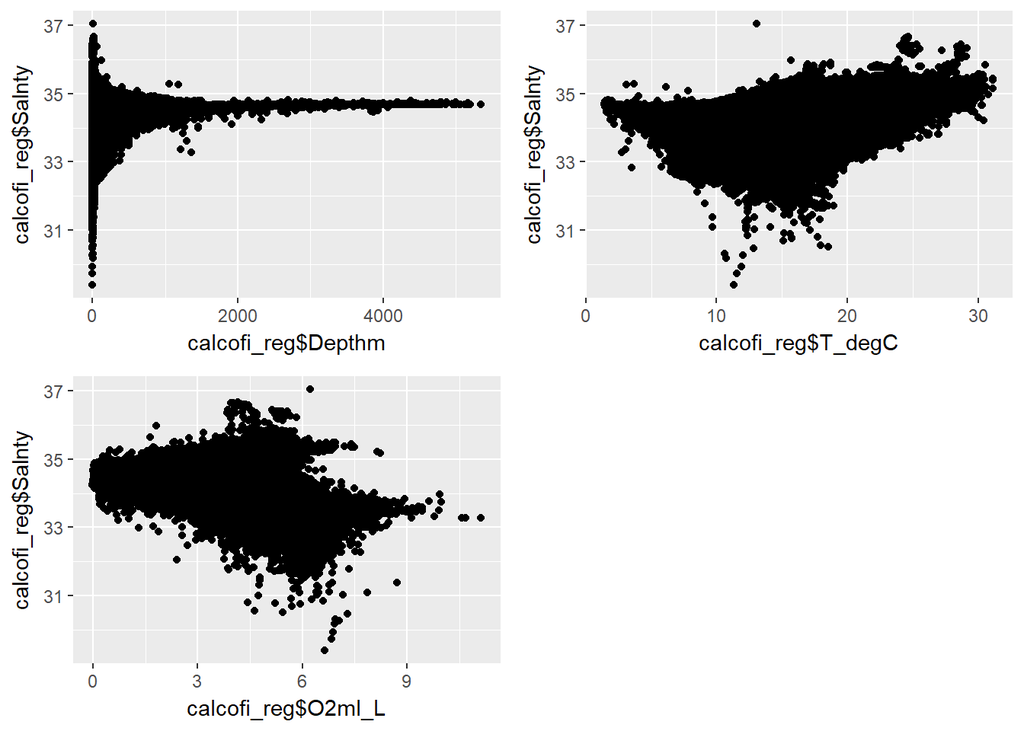

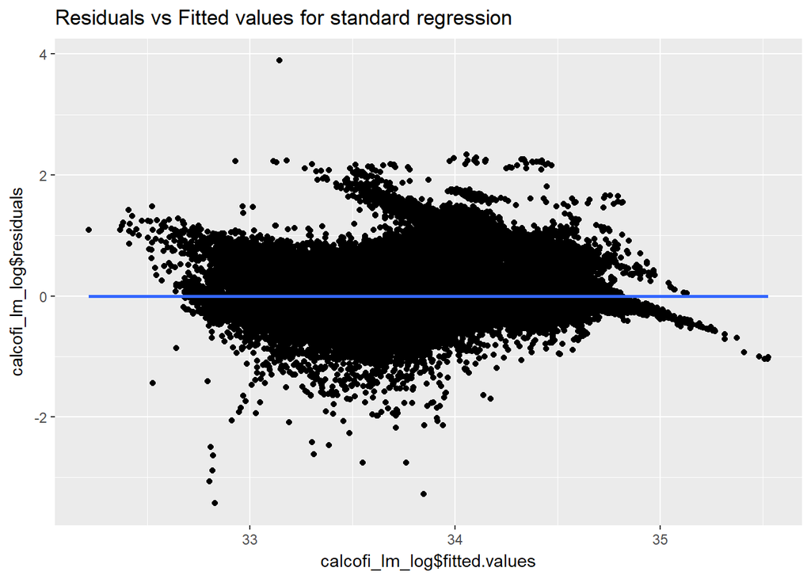

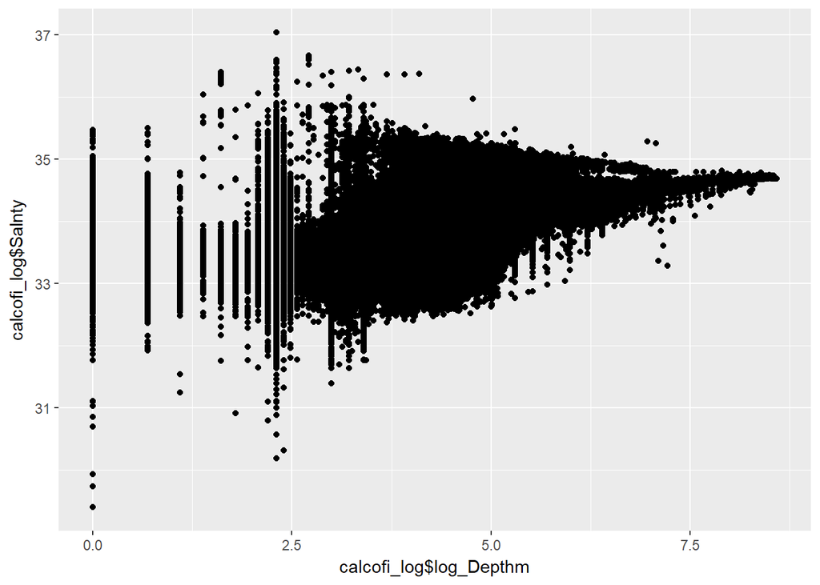

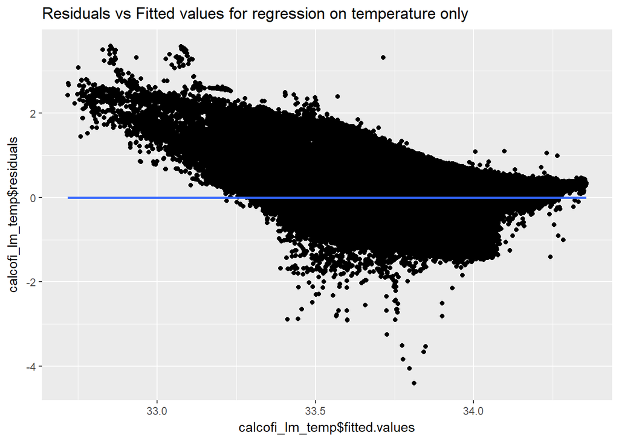